# Project Foundations for Data Science: FoodHub Data Analysis

**Marks: 60**

### Context

The number of restaurants in New York is increasing day by day. Lots of students and busy professionals rely on those restaurants due to their hectic lifestyles. Online food delivery service is a great option for them. It provides them with good food from their favorite restaurants. A food aggregator company FoodHub offers access to multiple restaurants through a single smartphone app.

The app allows the restaurants to receive a direct online order from a customer. The app assigns a delivery person from the company to pick up the order after it is confirmed by the restaurant. The delivery person then uses the map to reach the restaurant and waits for the food package. Once the food package is handed over to the delivery person, he/she confirms the pick-up in the app and travels to the customer's location to deliver the food. The delivery person confirms the drop-off in the app after delivering the food package to the customer. The customer can rate the order in the app. The food aggregator earns money by collecting a fixed margin of the delivery order from the restaurants.

### Objective

The food aggregator company has stored the data of the different orders made by the registered customers in their online portal. They want to analyze the data to get a fair idea about the demand of different restaurants which will help them in enhancing their customer experience. Suppose you are hired as a Data Scientist in this company and the Data Science team has shared some of the key questions that need to be answered. Perform the data analysis to find answers to these questions that will help the company to improve the business.

### Data Description

The data contains the different data related to a food order. The detailed data dictionary is given below.

### Data Dictionary

- order_id: Unique ID of the order
- customer_id: ID of the customer who ordered the food
- restaurant_name: Name of the restaurant
- cuisine_type: Cuisine ordered by the customer
- cost: Cost of the order
- day_of_the_week: Indicates whether the order is placed on a weekday or weekend (The weekday is from Monday to Friday and the weekend is Saturday and Sunday)
- rating: Rating given by the customer out of 5
- food_preparation_time: Time (in minutes) taken by the restaurant to prepare the food. This is calculated by taking the difference between the timestamps of the restaurant's order confirmation and the delivery person's pick-up confirmation.
- delivery_time: Time (in minutes) taken by the delivery person to deliver the food package. This is calculated by taking the difference between the timestamps of the delivery person's pick-up confirmation and drop-off information

### Let us start by importing the required libraries

```python
# Libraries to help with reading and manipulating data
import numpy as np
import pandas as pd

# Libraries to help with data visualization
import matplotlib.pyplot as plt
import seaborn as sns

# Command to tell Python to actually display the graphs
%matplotlib inline
```

```python
from google.colab import drive
drive.mount('/content/drive')
```

### Understanding the structure of the data

```python
# read the data
df = pd.read_csv('/content/drive/MyDrive/Python Course/AppliedDataScience/foodhub_order.csv')
# returns the first 5 rows
df.head()
```

|  | order_id | customer_id | restaurant_name | cuisine_type | cost_of_the_order | day_of_the_week | rating | food_preparation_time | delivery_time |
| --- | --- | --- | --- | --- | --- | --- | --- | --- | --- |
| 0 | 1477147 | 337525 | Hangawi | Korean | 30.75 | Weekend | Not given | 25 | 20 |
| 1 | 1477685 | 358141 | Blue Ribbon Sushi Izakaya | Japanese | 12.08 | Weekend | Not given | 25 | 23 |
| 2 | 1477070 | 66393 | Cafe Habana | Mexican | 12.23 | Weekday | 5 | 23 | 28 |
| 3 | 1477334 | 106968 | Blue Ribbon Fried Chicken | American | 29.20 | Weekend | 3 | 25 | 15 |
| 4 | 1478249 | 76942 | Dirty Bird to Go | American | 11.59 | Weekday | 4 | 25 | 24 |

#### Observations:

The DataFrame has 9 columns as mentioned in the Data Dictionary. Data in each row corresponds to the order placed by a customer.

```python
df = pd.read_csv('/content/drive/MyDrive/Python Course/AppliedDataScience/foodhub_order.csv', na_values=['?'])
```

```python
# Write your code here
# Find out what the shape of the data set is, how many rows and columns
df.shape
```

```
(1898, 9)
```

```python
# Write the code here
df.duplicated().sum()
```

```
0
```

```python
df.index
```

```
RangeIndex(start=0, stop=1898, step=1)
```

```python
df.columns
```

```
Index(['order_id', 'customer_id', 'restaurant_name', 'cuisine_type',
       'cost_of_the_order', 'day_of_the_week', 'rating',
       'food_preparation_time', 'delivery_time'],
      dtype='object')
```

```python
# Write the code here

df.restaurant_name.value_counts()
```

```
Shake Shack                  219
The Meatball Shop            132
Blue Ribbon Sushi            119
Blue Ribbon Fried Chicken     96
Parm                          68
                            ...
Sushi Choshi                   1
Dos Caminos Soho               1
La Follia                      1
Philippe Chow                  1
'wichcraft                     1
Name: restaurant_name, Length: 178, dtype: int64
```

```python
# Write the code here
df.restaurant_name.value_counts().head(10)
```

```
Shake Shack                      219
The Meatball Shop                132
Blue Ribbon Sushi                119
Blue Ribbon Fried Chicken         96
Parm                              68
RedFarm Broadway                  59
RedFarm Hudson                    55
TAO                               49
Han Dynasty                       46
Blue Ribbon Sushi Bar & Grill     44
Name: restaurant_name, dtype: int64
```

[figure not shown]

```python
# Write the code here

df.restaurant_name.value_counts().head(10).plot(kind='barh')
plt.xlabel('Rating')
plt.ylabel('Restaurant Name')
plt.title('Top 10 Rated Restaurants')
```

```python
df.count()
```

```
order_id                 1898
customer_id              1898
restaurant_name          1898
cuisine_type             1898
cost_of_the_order        1898
day_of_the_week          1898
rating                   1898
food_preparation_time    1898
delivery_time            1898
dtype: int64
```

#### Observations:

The data set has 1898 rows and 9 columns.

### **Question 2:** What are the datatypes of the different columns in the dataset? (The info() function can be used) [0.5 mark]

```python
# Use info() to print a concise summary of the DataFrame
df.info()
```

```
<class 'pandas.core.frame.DataFrame'>
RangeIndex: 1898 entries, 0 to 1897
Data columns (total 9 columns):
 #   Column                 Non-Null Count  Dtype
---  ------                 --------------  -----
 0   order_id               1898 non-null   int64
 1   customer_id            1898 non-null   int64
 2   restaurant_name        1898 non-null   object
 3   cuisine_type           1898 non-null   object
 4   cost_of_the_order      1898 non-null   float64
 5   day_of_the_week        1898 non-null   object
 6   rating                 1898 non-null   object
 7   food_preparation_time  1898 non-null   int64
 8   delivery_time          1898 non-null   int64
dtypes: float64(1), int64(4), object(4)
memory usage: 133.6+ KB
```

#### Observations: There are different attributes of different types(int, float,object) in the data. df.info shows float64(1): This indicates that there is 1 column in the DataFrame whose data type is float64. The float64 data type represents floating-point numbers, which are numbers with a decimal point. int64(4): This shows that there are 4 columns with the data type int64. The int64 data type is used for integer numbers, which are whole numbers (without a fractional part). object(4): This signifies that there are 4 columns that have the object data type. In pandas, object usually means the column has strings (text) or mixed types (numbers and text in the same column). It's the most general data type and is often used for columns with text or mixed data

### **Question 3:** Are there any missing values in the data? If yes, treat them using an appropriate method. [1 mark]

```python
df.isnull()
```

|  | order_id | customer_id | restaurant_name | cuisine_type | cost_of_the_order | day_of_the_week | rating | food_preparation_time | delivery_time |
| --- | --- | --- | --- | --- | --- | --- | --- | --- | --- |
| 0 | False | False | False | False | False | False | False | False | False |
| 1 | False | False | False | False | False | False | False | False | False |
| 2 | False | False | False | False | False | False | False | False | False |
| 3 | False | False | False | False | False | False | False | False | False |
| 4 | False | False | False | False | False | False | False | False | False |
| ... | ... | ... | ... | ... | ... | ... | ... | ... | ... |
| 1893 | False | False | False | False | False | False | False | False | False |
| 1894 | False | False | False | False | False | False | False | False | False |
| 1895 | False | False | False | False | False | False | False | False | False |
| 1896 | False | False | False | False | False | False | False | False | False |
| 1897 | False | False | False | False | False | False | False | False | False |

1898 rows × 9 columns

```python
df.isnull().sum()
```

```
order_id                 0
customer_id              0
restaurant_name          0
cuisine_type             0
cost_of_the_order        0
day_of_the_week          0
rating                   0
food_preparation_time    0
delivery_time            0
dtype: int64
```

```python
df.duplicated().sum()
```

```
0
```

```python
missing_ratings = df[df['rating'] == 'Not given'].shape[0]

# Print the number of missing ratings
print(f"Number of missing ratings: {missing_ratings}")
```

```
Number of missing ratings: 736
```

```python
df["rating"].apply(type).value_counts()
```

```
<class 'str'>    1898
Name: rating, dtype: int64
```

```python
#replacing the values stored as Not given to nan using the np.nan method.

df["rating"] = df["rating"].replace(["Not given"], np.nan)

#changing the data type to a integer
df["rating"] = df["rating"].astype(float)

print(df.head)
```

```
<bound method NDFrame.head of       order_id  customer_id                        restaurant_name  \
0      1477147       337525                                Hangawi
1      1477685       358141              Blue Ribbon Sushi Izakaya
2      1477070        66393                            Cafe Habana
3      1477334       106968              Blue Ribbon Fried Chicken
4      1478249        76942                       Dirty Bird to Go
...        ...          ...                                    ...
1893   1476701       292602  Chipotle Mexican Grill $1.99 Delivery
1894   1477421       397537                              The Smile
1895   1477819        35309                      Blue Ribbon Sushi
1896   1477513        64151                      Jack's Wife Freda
1897   1478056       120353                      Blue Ribbon Sushi

       cuisine_type  cost_of_the_order day_of_the_week  rating  \
0            Korean              30.75         Weekend     NaN
```

[output cut: 25 more lines]

```python
df.head()
```

|  | order_id | customer_id | restaurant_name | cuisine_type | cost_of_the_order | day_of_the_week | rating | food_preparation_time | delivery_time |
| --- | --- | --- | --- | --- | --- | --- | --- | --- | --- |
| 0 | 1477147 | 337525 | Hangawi | Korean | 30.75 | Weekend | NaN | 25 | 20 |
| 1 | 1477685 | 358141 | Blue Ribbon Sushi Izakaya | Japanese | 12.08 | Weekend | NaN | 25 | 23 |
| 2 | 1477070 | 66393 | Cafe Habana | Mexican | 12.23 | Weekday | 5.0 | 23 | 28 |
| 3 | 1477334 | 106968 | Blue Ribbon Fried Chicken | American | 29.20 | Weekend | 3.0 | 25 | 15 |
| 4 | 1478249 | 76942 | Dirty Bird to Go | American | 11.59 | Weekday | 4.0 | 25 | 24 |

```python
df.info()
```

```
<class 'pandas.core.frame.DataFrame'>
RangeIndex: 1898 entries, 0 to 1897
Data columns (total 9 columns):
 #   Column                 Non-Null Count  Dtype
---  ------                 --------------  -----
 0   order_id               1898 non-null   int64
 1   customer_id            1898 non-null   int64
 2   restaurant_name        1898 non-null   object
 3   cuisine_type           1898 non-null   object
 4   cost_of_the_order      1898 non-null   float64
 5   day_of_the_week        1898 non-null   object
 6   rating                 1162 non-null   float64
 7   food_preparation_time  1898 non-null   int64
 8   delivery_time          1898 non-null   int64
dtypes: float64(2), int64(4), object(3)
memory usage: 133.6+ KB
```

#### Observations:

The data set contained a column "rating" that when checked for the data type was showing to be stored as an object. After using np.nan to replace all the entries that contained "Not given", the column of rating, now shows to be stored as a float64. Additionally there are no duplications in the data.

### **Question 4:** Check the statistical summary of the data. What is the minimum, average, and maximum time it takes for food to be prepared once an order is placed? [2 marks]

```python
# To get a statistical summary of the entire DataFrame
df.describe().T
```

|  | count | mean | std | min | 25% | 50% | 75% | max |
| --- | --- | --- | --- | --- | --- | --- | --- | --- |
| order_id | 1898.0 | 1.477496e+06 | 548.049724 | 1476547.00 | 1477021.25 | 1477495.50 | 1.477970e+06 | 1478444.00 |
| customer_id | 1898.0 | 1.711685e+05 | 113698.139743 | 1311.00 | 77787.75 | 128600.00 | 2.705250e+05 | 405334.00 |
| cost_of_the_order | 1898.0 | 1.649885e+01 | 7.483812 | 4.47 | 12.08 | 14.14 | 2.229750e+01 | 35.41 |
| rating | 1162.0 | 4.344234e+00 | 0.741478 | 3.00 | 4.00 | 5.00 | 5.000000e+00 | 5.00 |
| food_preparation_time | 1898.0 | 2.737197e+01 | 4.632481 | 20.00 | 23.00 | 27.00 | 3.100000e+01 | 35.00 |
| delivery_time | 1898.0 | 2.416175e+01 | 4.972637 | 15.00 | 20.00 | 25.00 | 2.800000e+01 | 33.00 |

```python
# Write the code here

min_prep_time = df['food_preparation_time'].min()
avg_prep_time = df['food_preparation_time'].mean()
max_prep_time = df['food_preparation_time'].max()

print(f"Minimum Preparation Time: {min_prep_time} minutes")
print(f"Average Preparation Time: {avg_prep_time} minutes")
print(f"Maximum Preparation Time: {max_prep_time} minutes")
```

```
Minimum Preparation Time: 20 minutes
Average Preparation Time: 27.371970495258168 minutes
Maximum Preparation Time: 35 minutes
```

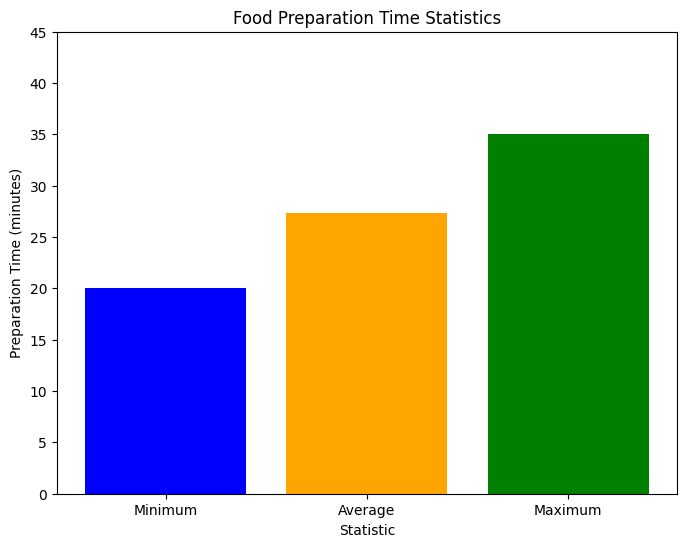

```python
# Write the code here
min_prep_time = df['food_preparation_time'].min()
avg_prep_time = df['food_preparation_time'].mean()
max_prep_time = df['food_preparation_time'].max()

times = ['Minimum', 'Average', 'Maximum']
values = [min_prep_time, avg_prep_time, max_prep_time]

plt.figure(figsize=(8, 6))
plt.bar(times, values, color=['blue', 'orange', 'green'])
plt.xlabel('Statistic')
plt.ylabel('Preparation Time (minutes)')
plt.title('Food Preparation Time Statistics')
plt.xticks(times)
plt.ylim(0, max(values) + 10)

plt.show()
```

```python
print(df.min())
```

```
order_id                    1476547
customer_id                    1311
restaurant_name          'wichcraft
cuisine_type               American
cost_of_the_order              4.47
day_of_the_week             Weekday
rating                          3.0
food_preparation_time            20
delivery_time                    15
dtype: object
```

[figure not shown]

```python
# top 5 rated restuarants and their ratings


df.restaurant_name.value_counts().head(5).plot(kind='barh')
plt.xlabel('Rating')
plt.ylabel('Restaurant Name')
plt.title('Top 5 Rated Restaurants')
df.groupby('restaurant_name').rating.mean().sort_values(ascending=False).head(5).plot(kind='box')
plt.xlabel('Restaurant Name')
plt.ylabel('Rating')
plt.title('Box Plot of Top 5 Rated Restaurants')
```

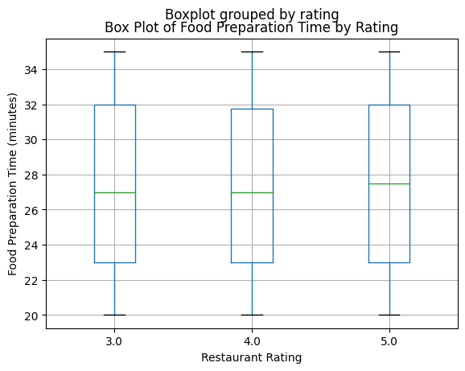

```python
  # prompt: Create a vizualization that shows the correlation between rating and food_preperation_time  do so using a boxplot

df.boxplot(column=['food_preparation_time'], by='rating')
plt.xlabel('Restaurant Rating')
plt.ylabel('Food Preparation Time (minutes)')
plt.title('Box Plot of Food Preparation Time by Rating')
```

```python
df.mean()
```

```
order_id                 1.477496e+06
customer_id              1.711685e+05
cost_of_the_order        1.649885e+01
rating                   4.344234e+00
food_preparation_time    2.737197e+01
delivery_time            2.416175e+01
dtype: float64
```

```python
print(df.max())
```

```
order_id                    1478444
customer_id                  405334
restaurant_name           indikitch
cuisine_type             Vietnamese
cost_of_the_order             35.41
day_of_the_week             Weekend
rating                          5.0
food_preparation_time            35
delivery_time                    33
dtype: object
```

#### Observations:

Minimum Preparation Time: 20 minutes Average Preparation Time: 27.37 minutes Maximum Preparation Time: 35 minutes